# Indvidual attitudes towards homosexuality and homosexual couples: testing Ronald Inglehart’s postmaterialism theory

Alba Proficuo, Erica Ravarelli

# Introduction

This short paper is aimed at exploring the relation between level of education and individual opinions about homosexuality and homosexual couples’ rights in 81 countries. The analysis relies on data coming from the joint version of European Values Study and World Values Survey (Joint EVS/WVS), conducted between 2017 and 2021 (DatasetZA7505).

Over the last decades, the issue of homosexual people’s and couples’ rights has rapidly become one of most debated ones. Starting from the end of the XX century, the mean level of tolerance towards same-sex relationships increased, although non-negligible differences persist across countries. (Smith et al., 2014). Based on Ronald Inglehart’s theory of postmaterlism, it is plausible to expect that high-income people tend to show a more tolerant attitude towards homosexual people and couples(Inglehart, 2009). This theory will be put into the form of falsifiable hypothesis using the variable “level of education” as a proxy for individual economic situation, based on previous studies which demonstrate that highest levels of education are usually associated with wealthier economic conditions. The following hypothesis will, therefore, be tested:

H1: More tolerant attitudes towards homosexual people are displayed by higher-educated people

H2: More tolerant attitudes towards homosexual couples are displayed by higher-educated people

# Data and method

We took into consideration three variables: D081, F118 and X025R. In the first one the respondents had to express their level of agreement with the statement: ‘Homosexual couples are as good parents as other couples’. In the second one the respondents had to say how much justifiable homosexuality is on a scale from 1 to 10. Finally, the last one is about the level of education of the respondents from 1 to 3. Then, from the variable of interest, we removed the negative values and did some data preparation for the regression models.

```r
library(tidyverse)
library(rio)
library(ggeffects)
library(texreg)
europeanvalues <- import("ZA7505_v2-0-0.dta")


table(europeanvalues$D081)
```

```
##
##    -5    -4    -2    -1     1     2     3     4     5
##    89  8710   896  7645 16377 25677 22170 28186 25250
```

```r
table(europeanvalues$F118)
```

```
##
##    -5    -4    -2    -1     1     2     3     4     5     6     7     8     9
##    59  2400  1604  3602 52776  6726  5470  4409 13507  5747  4651  5714  4198
##    10
## 24137
```

```r
table(europeanvalues$X025A_01)
```

```
##
##    -5    -2    -1     0     1     2     3     4     5     6     7     8
##   141   735   205  4636 12953 19034 43204  9911 10637 19374 12700  1470
```

```r
europeanvalues <-mutate(
  europeanvalues,
  homo_parents = ifelse(europeanvalues$D081 == 1,"Agree strongly",
                        ifelse(europeanvalues$D081 == 2, "Agree",
                               ifelse(europeanvalues$D081 == 3, "Neither agree nor disagree",
                                      ifelse(europeanvalues$D081 == 4, "Disagree",
                                             ifelse(europeanvalues$D081 == 5, "Disagree strongly",
                                                    "missing"
))))))


table(europeanvalues$homo_parents)
```

```
##
##                      Agree             Agree strongly
##                      25677                      16377
##                   Disagree          Disagree strongly
##                      28186                      25250
##                    missing Neither agree nor disagree
##                      17340                      22170
```

```r
europeanvalues <-mutate(
  europeanvalues,
  justifiable_homo = ifelse(europeanvalues$F118 <= 2, "Never justifiable",
                            ifelse(europeanvalues$F118 <= 4, "Sometimes justifiable",
                                   ifelse(europeanvalues$F118 <= 6, "Neither justifiable nor not",
                                          ifelse(europeanvalues$F118 <= 8, "Often justifiable",
                                                 ifelse(europeanvalues$F118 <= 10, "Always justifiable",
                                                        "missing"
                                                 ))))))
table(europeanvalues$justifiable_homo)
```

```
##
##          Always justifiable Neither justifiable nor not
##                       28335                       19254
##           Never justifiable           Often justifiable
##                       67167                       10365
##       Sometimes justifiable
##                        9879
```

```r
europeanvalues <-mutate(
  europeanvalues,
  edu_level = ifelse(europeanvalues$X025R == 1, "Lower",
                     ifelse(europeanvalues$X025R == 2, "Middle",
                            ifelse(europeanvalues$X025R == 3, "Upper",
                                   "missing"
                            ))))
table(europeanvalues$edu_level)
```

```
##
##   Lower  Middle missing   Upper
##   36623   53115    1081   44181
```

```r
table(europeanvalues$homo_parents)
```

```
##
##                      Agree             Agree strongly
##                      25677                      16377
##                   Disagree          Disagree strongly
##                      28186                      25250
##                    missing Neither agree nor disagree
##                      17340                      22170
```

```r
table(europeanvalues$justifiable_homo)
```

```
##
##          Always justifiable Neither justifiable nor not
##                       28335                       19254
##           Never justifiable           Often justifiable
##                       67167                       10365
##       Sometimes justifiable
##                        9879
```

```r
table(europeanvalues$edu_level)
```

```
##
##   Lower  Middle missing   Upper
##   36623   53115    1081   44181
```

```r
tab_int <-select(europeanvalues, homo_parents, justifiable_homo, edu_level)
```

```r
str(tab_int)
```

```
## 'data.frame':    135000 obs. of  3 variables:
##  $ homo_parents    : chr  "Disagree" "missing" "Disagree strongly" "Disagree strongly" ...
##  $ justifiable_homo: chr  "Never justifiable" "Neither justifiable nor not" "Never justifiable" "Never justifiable" ...
##  $ edu_level       : chr  "Middle" "Middle" "Lower" "Lower" ...
```

```r
tab_int <- mutate(
  tab_int,
  homo_par_rel = fct_relevel(homo_parents,
                             "Disagree strongly", "Disagree", "Neither agree nor disagree",
                             "Agree", "Agree strongly"))


plot_homop<- filter(
  tab_int,
  homo_par_rel %in% c("Disagree strongly", "Disagree", "Neither agree nor disagree", "Agree", "Agree strongly"),
  edu_level %in% c("Lower", "Middle", "Upper"))



tab_int <- mutate(
  tab_int,
  just_homo_rel = fct_relevel(justifiable_homo,
                              "Never justifiable", "Sometimes justifiable", "Neither justifiable nor not",
                              "Often justifiable", "Always justifiable"))


plot_homojust<- filter(
  tab_int,
  just_homo_rel %in% c("Never justifiable", "Sometimes justifiable", "Neither justifiable nor not",
                       "Often justifiable", "Always justifiable"),
  edu_level %in% c("Lower", "Middle", "Upper"))



tab_homp <- select(europeanvalues, D081, X025R)


tab_homp_reg <- mutate(tab_homp,
   homo_parents_reg = recode(D081,
                              `1` = 5,
                              `2` = 4,
                              `3` = 3,
                              `4` = 2,
                              `5` = 1
                              ))


tab_homp_reg <- filter (tab_homp_reg, homo_parents_reg > 0, X025R > 0)

min(tab_homp_reg$homo_parents_reg)
```

```
## [1] 1
```

```r
tab_homp_reg <- rename(
  tab_homp_reg,
  edu_level = X025R
)
names(tab_homp_reg)
```

```
## [1] "D081"             "edu_level"        "homo_parents_reg"
```

```r
tab_homojust <- select(europeanvalues, F118,X025R)


tab_homojust_reg <- mutate(tab_homojust,
    homo_just_reg = recode(F118,
                              `1` = 1,
                              `2` = 1,
                              `3` = 2,
                              `4` = 2,
                              `5` = 3,
                              `6` = 3,
                              `7` = 4,
                              `8` = 4,
                              `9` = 5,
                              `10`= 5
    ))




tab_homojust_reg <- filter (tab_homojust_reg, homo_just_reg > 0, X025R > 0)
min(tab_homojust_reg$homo_just_reg)
```

```
## [1] 1
```

```r
tab_homojust_reg <- rename(
  tab_homojust_reg,
  edu_level = X025R
)
names(tab_homojust_reg)
```

```
## [1] "F118"          "edu_level"     "homo_just_reg"
```

```r
min(tab_homojust_reg$homo_just_reg)
```

```
## [1] 1
```

## Plots and regression models

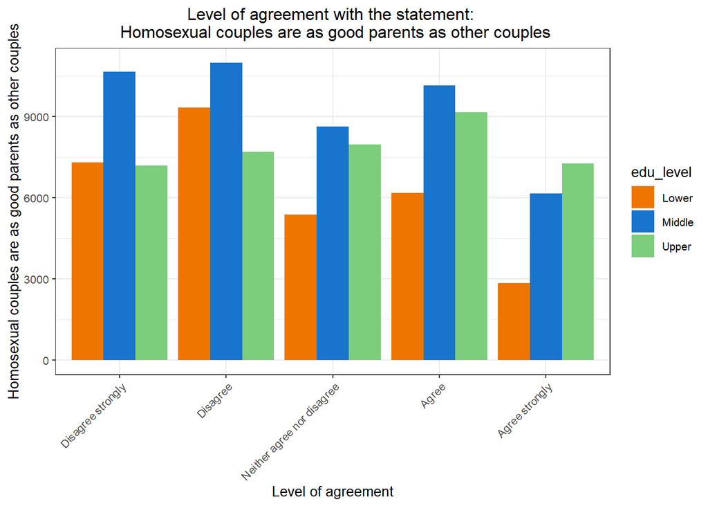

```r
ggplot(plot_homop, aes(x=homo_par_rel, fill = edu_level)) +
  geom_bar(position = "dodge") +
  scale_fill_manual(values = c("darkorange2", "dodgerblue3", "palegreen3")) +
  ggtitle("Level of agreement with the statement: \n Homosexual couples are as good parents as other couples") +
  ylab("Homosexual couples are as good parents as other couples") +
  xlab("Level of agreement") +
  theme_bw(base_size = 10) +
  theme(axis.text.x=element_text(angle=45,hjust=1)) +
  theme(plot.title = element_text(hjust = 0.5))
```

This bar-chart allows us to see that the number of lower educated people who strongly agree with the statement: ‘Homosexual couples are as good parents as other couples’, is much lower than the number of upper educated people who strongly agree with the statement. Instead the difference between lower and upper educated people within the category ‘strongly disagree’ is almost null.

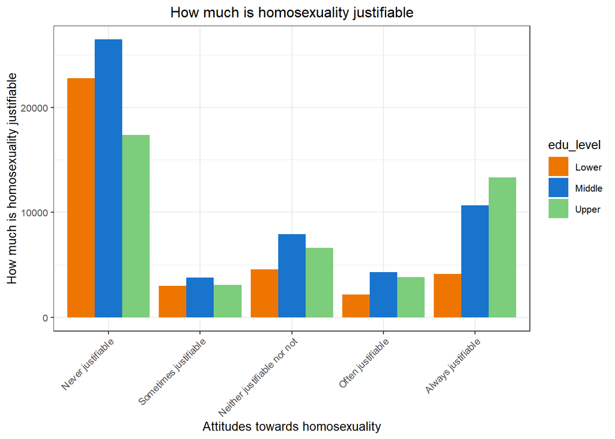

```r
ggplot(plot_homojust, aes(x=just_homo_rel, fill = edu_level)) +
  geom_bar(position = "dodge") +
  scale_fill_manual(values = c("darkorange2", "dodgerblue3", "palegreen3")) +
  ggtitle("How much is homosexuality justifiable") +
  ylab("How much is homosexuality justifiable") +
  xlab("Attitudes towards homosexuality") +
  theme_bw(base_size = 10) +
  theme(axis.text.x=element_text(angle=45,hjust=1)) +
  theme(plot.title = element_text(hjust = 0.5))
```

This bar chart allows us to visualize the fact that the number of lower educated people who think that homosexuality is never justifiable is higher than the number of higher educated people who think the same thing. On the other hand, the number of higher educated people who think that homosexuality is always justifiable is much higher than the number of lower educated people who think the same thing.

```r
reg1 <- lm(homo_parents_reg ~ factor(edu_level),
           data = tab_homp_reg)
summary(reg1)
```

```
##
## Call:
## lm(formula = homo_parents_reg ~ factor(edu_level), data = tab_homp_reg)
##
## Residuals:
##      Min       1Q   Median       3Q      Max
## -2.04176 -1.04176 -0.04176  1.21118  2.38855
##
## Coefficients:
##                    Estimate Std. Error t value Pr(>|t|)
## (Intercept)        2.611446   0.007658  341.02   <2e-16 ***
## factor(edu_level)2 0.177374   0.009883   17.95   <2e-16 ***
## factor(edu_level)3 0.430309   0.010244   42.00   <2e-16 ***
## ---
## Signif. codes:  0 '***' 0.001 '**' 0.01 '*' 0.05 '.' 0.1 ' ' 1
##
## Residual standard error: 1.348 on 116752 degrees of freedom
## Multiple R-squared:  0.0154, Adjusted R-squared:  0.01538
## F-statistic: 912.8 on 2 and 116752 DF,  p-value: < 2.2e-16
```

```r
pred1 <- ggpredict(reg1, terms = "edu_level")
pred1
```

```
## # Predicted values of homo_parents_reg
##
## edu_level | Predicted |       95% CI
## ------------------------------------
##         1 |      2.61 | [2.60, 2.63]
##         2 |      2.79 | [2.78, 2.80]
##         3 |      3.04 | [3.03, 3.06]
```

In this first regression it’s shown how compared to the reference category, which corresponds to the lower lever of education, both the coefficients corresponding to middle and upper education are positive. This means that higher the level of education is, higher will be the level of agreement with the statement saying that homosexual couples are as good as other couples.

```r
reg2 <- lm(homo_just_reg ~ factor(edu_level),
           data = tab_homojust_reg)
summary(reg2)
```

```
##
## Call:
## lm(formula = homo_just_reg ~ factor(edu_level), data = tab_homojust_reg)
##
## Residuals:
##     Min      1Q  Median      3Q     Max
## -1.9356 -1.4969 -0.4969  1.5031  2.9765
##
## Coefficients:
##                    Estimate Std. Error t value Pr(>|t|)
## (Intercept)        2.023538   0.008634  234.38   <2e-16 ***
## factor(edu_level)2 0.473357   0.011201   42.26   <2e-16 ***
## factor(edu_level)3 0.912034   0.011648   78.30   <2e-16 ***
## ---
## Signif. codes:  0 '***' 0.001 '**' 0.01 '*' 0.05 '.' 0.1 ' ' 1
##
## Residual standard error: 1.6 on 126408 degrees of freedom
## Multiple R-squared:  0.04632,    Adjusted R-squared:  0.0463
## F-statistic:  3070 on 2 and 126408 DF,  p-value: < 2.2e-16
```

```r
pred2<- ggpredict(reg2, terms = "edu_level")
pred2
```

```
## # Predicted values of homo_just_reg
##
## edu_level | Predicted |       95% CI
## ------------------------------------
##         1 |      2.02 | [2.01, 2.04]
##         2 |      2.50 | [2.48, 2.51]
##         3 |      2.94 | [2.92, 2.95]
```

Also in the second regression we see that, compared to the reference category which corresponds to the lower lever of education, both the coefficients are positive. This means that higher level of education corresponds to more tolerant attitude towards homosexuality.

```r
htmlreg(list(reg1, reg2),
        custom.model.names = c("attitude towards homosexual couples", "attitude towards homosexuality"),
        caption = "Regression models for attitude towards homosexual couples and towards homosexuality")
```

Regression models for attitude towards homosexual couples and towards homosexuality

|  | attitude towards homosexual couples | attitude towards homosexuality |
| --- | --- | --- |
| (Intercept) | 2.61*** | 2.02*** |
|  | (0.01) | (0.01) |
| factor(edu_level)2 | 0.18*** | 0.47*** |
|  | (0.01) | (0.01) |
| factor(edu_level)3 | 0.43*** | 0.91*** |
|  | (0.01) | (0.01) |
| R<sup>2</sup> | 0.02 | 0.05 |
| Adj. R<sup>2</sup> | 0.02 | 0.05 |
| Num. obs. | 116755 | 126411 |

p < 0.001; p < 0.01; p < 0.05

# Conclusion

Observing the bar-charts and the regressions we can conclude that, overall, people with higher levels of education tend to be more tolerant towards homosexual couples and homosexuality in general. However, not all the results we obtained met our expectations. For example, the difference between lower and upper educated people within the category ‘strongly disagree’ is almost null, this is probably due to the fact that we are observing 81 countries all together, where the respondents normally have different cultural backgrounds.

## References

Inglehart, R. (2009). Postmaterialist Values and the Shift from Survival to Self‐Expression Value,*The Oxford Handbook of Political Behavior*.

Smith, T. W., Son, J., Kim, J. (2014). Public Attitudes towards Homosexuality and Gay Rights across Time and Countries. The Williams Institute.